# act_report

## Report: act_report

### Insights

Three insights can be retrieved from the Twitter dataset.

**First**, we identified the two dog breeds that were mostly tweeted and retweeted by the users There are 114 dog breeds shared by the users and *'Golden_retriever'* is the most tweeted by users with a frequency of 170 from 1170 records, and *'Labrador_retriever'* comes in a second place with a frequency of 105. The *'Golden retriever'* and *'Labrador_retriever'* are to be known the most popular dog breeds in the united states and it is their friendly and tolerant attitude that makes them great family pets. Labradors are also known to be playful and easy to train.

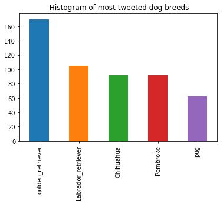

Although the *'Golden_retriever'* is the most sent dog breed by users, the *'Labrador_retriever'* is the one that caught all the attention and was the most retweeted, then comes *'Eskimo_dog'* secondly and *'Chihuahua'* in a third place. This is relatively expected as for the 29th year in a row, the *Labrador retriever* has emerged victorious as America's number one breed, according to a list [released](https://www.smithsonianmag.com/smart-news/labrador-tops-most-popular-dog-breed-list-29th-year-row-180974808/) by the American Kennel Club (AKC) on May 1.

**Second**, we wanted to see if there is any correlation between retweet_count and favorite_count. In the figure below, there is a positive correlation between retweet_count and favorite_count which means that generally users tend to retweet more their favorite images. We can also notice that although some images have high retweet counts (between 10000 and 20000), their favorite count remained null.

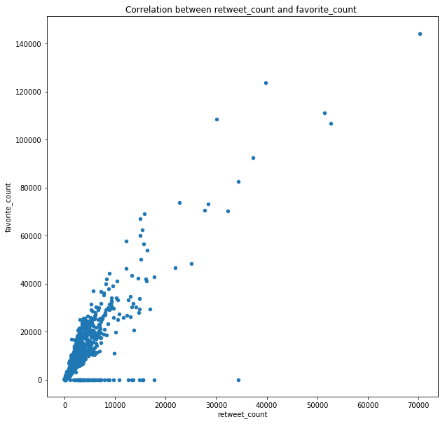

**Third** we wanted to know the top 20 dog breed/dog_stage that had the highest rating numerator. We sorted the values of rating_numerator in a descending order and found that:

- For dog stage, the *'pupper'* and *'doggo'* were in the top 20 of rated dog_stage with a rating of 14/10. It is quite logical that these stages take over *'puppo'* and *'floofer'* as they were the most sent by users.
- For dog breed, the *Old_English_sheepdog* was the highly rated breed with a score of 14/10 and then we had *Pembroke* in a second place. Surprisingly, *Golden retriver* was not among the top 20 rated breeds and *Labrador retriver* came only in the 15th place.

### Visualization

The following charts represent the repartition of averages of *favorite_count* and *rating_numerator* for each dog stage.

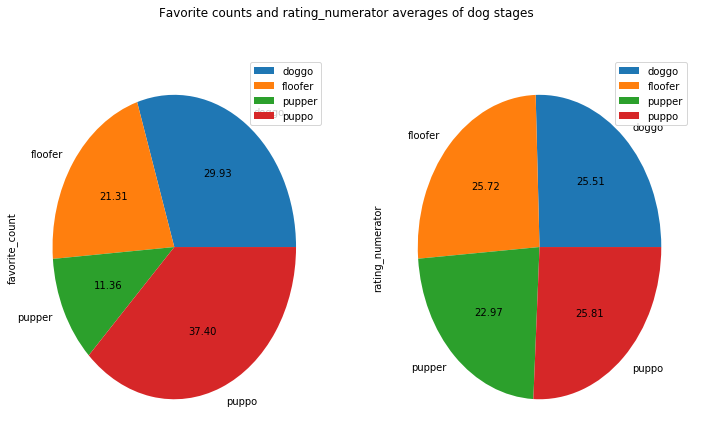